# Linear Regression: Day 2

Author

Constantin Manuel Bosancianu

Published

February 26, 2019

# 1 Introduction

We can continue with the SAT score data from yesterday. We will gradually add a bit more complexity to our model today, under the form of additional predictors.

```r
library(pacman)
p_load(readstata13, tidyverse, psych, corrgram, car, knitr,
       texreg, kableExtra, magrittr, ggthemes)

# Avoid scientific notation for coefficients
options(scipen = 8)
```

# 2 Reading data

We read in the data using the same function from the `readstata13` package as yesterday.

```r
df_sat <- read.dta13(file = "../02-data/01-Education-states.dta",
                     convert.factors = TRUE)
```

# 3 Simple linear regression

We start by running the model we finished yesterday’s class with: $CSAT \leftarrow expenses$.

## 3.1 Initial regression

```r
model1 <- lm(csat ~ expense,
             data = df_sat,
             na.action = na.omit)

summary(model1)
```

```
Call:
lm(formula = csat ~ expense, data = df_sat, na.action = na.omit)

Residuals:
     Min       1Q   Median       3Q      Max
-131.811  -38.085    5.607   37.852  136.495

Coefficients:
               Estimate  Std. Error t value Pr(>|t|)
(Intercept) 1060.732444   32.700897   32.44  < 2e-16 ***
expense       -0.022276    0.006037   -3.69 0.000563 ***
---
Signif. codes:  0 '***' 0.001 '**' 0.01 '*' 0.05 '.' 0.1 ' ' 1

Residual standard error: 59.81 on 49 degrees of freedom
Multiple R-squared:  0.2174,    Adjusted R-squared:  0.2015
F-statistic: 13.61 on 1 and 49 DF,  p-value: 0.0005631
```

Of course, when interpreting the intercept, it makes no sense to talk about the predicted average SAT score for a state with 0 USD spent on education. We can solve this by rescaling the predictor.

```r
df_sat %<>%
    mutate(exp_scale = expense - mean(expense, na.rm = TRUE))
```

```r
rm(model1)

model2 <- lm(csat ~ exp_scale,
             data = df_sat,
             na.action = na.omit)
summary(model2)
```

```
Call:
lm(formula = csat ~ exp_scale, data = df_sat, na.action = na.omit)

Residuals:
     Min       1Q   Median       3Q      Max
-131.811  -38.085    5.607   37.852  136.495

Coefficients:
              Estimate Std. Error t value Pr(>|t|)
(Intercept) 944.098039   8.375592  112.72  < 2e-16 ***
exp_scale    -0.022276   0.006037   -3.69 0.000563 ***
---
Signif. codes:  0 '***' 0.001 '**' 0.01 '*' 0.05 '.' 0.1 ' ' 1

Residual standard error: 59.81 on 49 degrees of freedom
Multiple R-squared:  0.2174,    Adjusted R-squared:  0.2015
F-statistic: 13.61 on 1 and 49 DF,  p-value: 0.0005631
```

If you’re going to do this centering again and again, it makes sense to leverage `R`’s power and create a custom function for this.[^1]

<sup>1</sup> Just remember, this is a function that is defined only for this `R` session. You will need to define it again for other projects.

```r
fun_center <- function(x) {
    x - mean(x, na.rm = TRUE)
}
```

```r
df_sat %<>%
    mutate(exp_scale = fun_center(expense))
```

Re-run the model to see that nothing has changed.

```r
model2 <- lm(csat ~ exp_scale,
             data = df_sat,
             na.action = na.omit)

summary(model2)
```

```
Call:
lm(formula = csat ~ exp_scale, data = df_sat, na.action = na.omit)

Residuals:
     Min       1Q   Median       3Q      Max
-131.811  -38.085    5.607   37.852  136.495

Coefficients:
              Estimate Std. Error t value Pr(>|t|)
(Intercept) 944.098039   8.375592  112.72  < 2e-16 ***
exp_scale    -0.022276   0.006037   -3.69 0.000563 ***
---
Signif. codes:  0 '***' 0.001 '**' 0.01 '*' 0.05 '.' 0.1 ' ' 1

Residual standard error: 59.81 on 49 degrees of freedom
Multiple R-squared:  0.2174,    Adjusted R-squared:  0.2015
F-statistic: 13.61 on 1 and 49 DF,  p-value: 0.0005631
```

Now, at least, the intercept makes sense. How would you interpret it with this version of the predictor?

# 4 Model fit

Initial questions:

1. What is the residual standard error in the model?
2. How do you interpret the R-squared value? (`R` calls this the *multiple R-squared*)

These are important summary statistics, and although sometimes they get abused (particularly the R-squared), they tell us important things. At the same time, they cannot replace a thorough look at how the model does in **PREDICTING** the data: where does it predict well, and where does it do poorly?

For that, all you need to ask for is the predicted (fitted) values, which the function already computes and stores in the model object.

```r
model2$fitted.values
```

```
       1        2        3        4        5        6        7        8
979.9387 875.1763 964.7467 978.3126 960.6925 947.9286 891.3930 930.0858
       9       10       11       12       13       14       15       16
854.4822 943.2061 961.2494 945.6565 985.3071 937.7709 950.9135 956.5047
      17       18       19       20       21       22       23       24
952.1609 963.7443 968.3776 939.1520 914.4706 918.9257 929.6848 944.0303
      25       26       27       28       29       30       31       32
989.7400 954.8340 944.8100 948.5077 957.0839 934.3850 868.1595 973.9688
      33       34       35       36       37       38       39       40
869.9415 960.7593 967.1970 943.8967 976.2855 934.1400 915.0274 919.4380
      41       42       43       44       45       46       47       48
963.8111 972.4095 976.4860 961.8731 994.7965 910.6391 953.0074 949.3542
      49       50       51
951.3368 929.9521 933.2489
```

In their raw form they don’t tell us very much, so we might want to actually plot them against the actual values for `csat`. We can plot these using the same function as yesterday, from the `ggplot2` package.

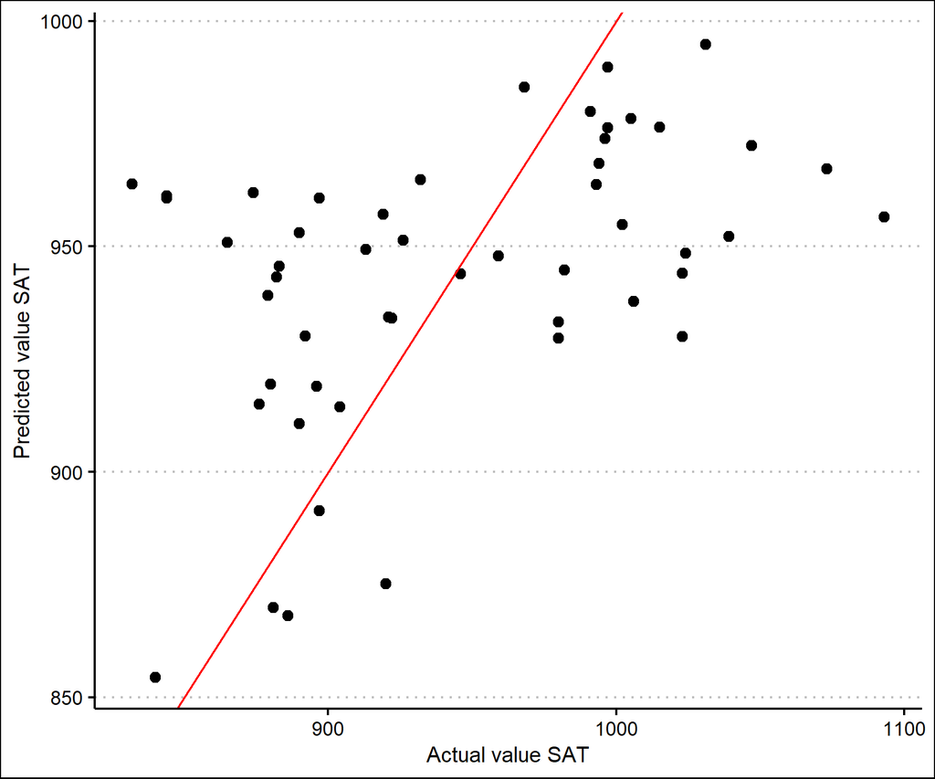

```r
ggplot(NULL, aes(x = df_sat$csat,
                 y = model2$fitted.values)) +
  geom_point(size = 2) +
  xlab("Actual value SAT") +
  ylab("Predicted value SAT") +
  theme_clean() +
  geom_abline(intercept = 0,
              slope = 1,
              color = "red")
```

You can see that at low levels of SAT scores we are overpredicting, and at high levels of SAT scores, we are underpredicting. The differences are quite substantial: we are frequently talking about 50-100 SAT points.

# 5 Multiple linear regression

What if we’re actually dealing with a self-selection effect? A number of insights lead us to believe that this is the case:

1. As one of the participants has suggested, the SAT has a competitor, the ACT. Some students might opt for the SAT because they have a particular set of colleges they would like to attend, and they only apply to them.
2. Some states offer the SAT to all students free of charge (the recent list includes District of Columbia, Idaho, Maine). Others require it of their students (the recent list includes Colorado, Illinois, New Hampshire).
3. Some states might simply be better at incentivizing students to take the SAT, and at offering them assistance for the test, or publicizing the benefits of taking the SAT.

Whatever the reason, if a larger group takes the SAT, we would expect that there is a greater diversity in test scorers, which means lower average scores. In states where students are allowed to self-select into taking the test, we expect better students to opt for it, and therefore we expect to see higher average scores. In this sense, it’s not that some states are worse in educational provision than others - it’s just a different composition of students taking the SAT.

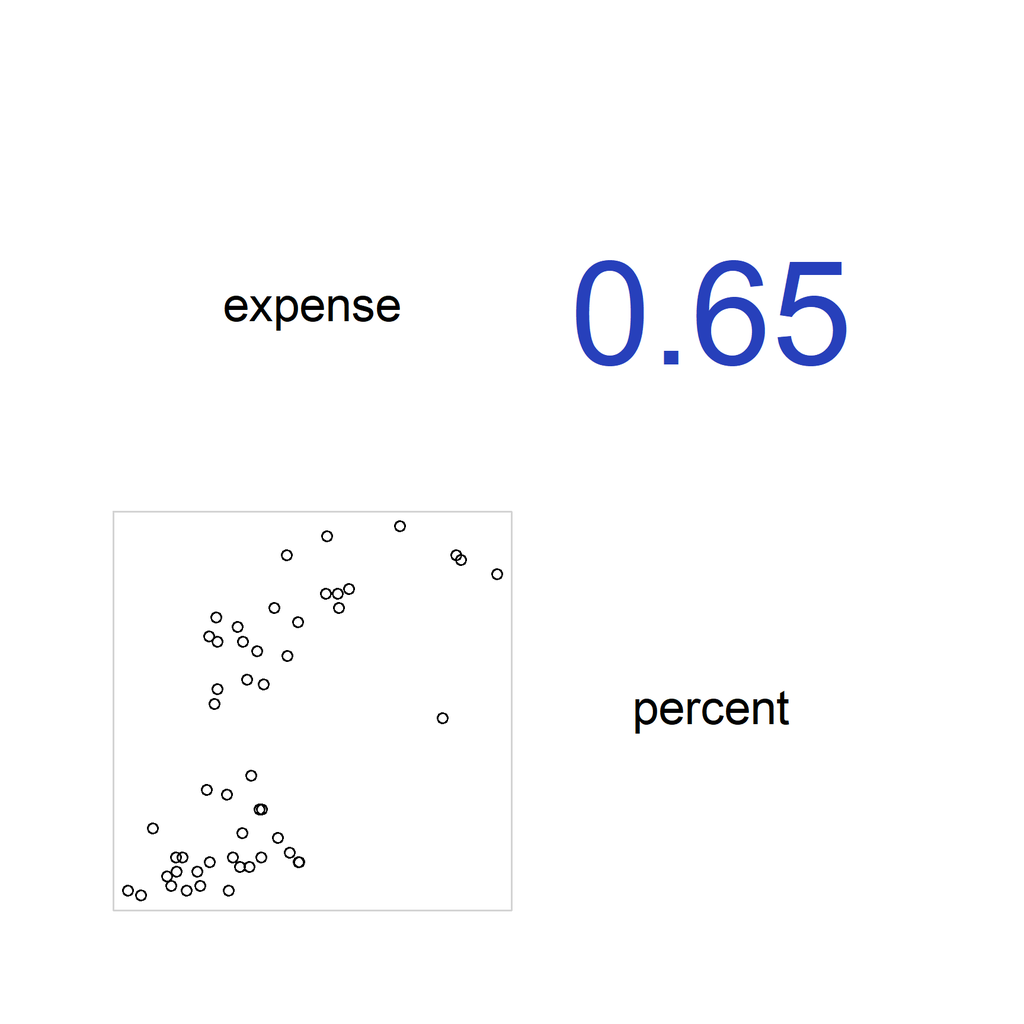

```r
corrgram(df_sat[, c("expense", "percent")],
         lower.panel = panel.pts,
         upper.panel = panel.cor)
```

We see there is a fairly high correlation between the two indicators.

Perform the same centering for `percent` as well, so as not to interpret the intercept as the SAT score in a state where 0% of students take the SAT.

```r
df_sat %<>%
    mutate(per_scale = fun_center(percent))
```

```r
model3 <- lm(csat ~ exp_scale + per_scale,
             data = df_sat,
             na.action = na.omit)

summary(model3)
```

```
Call:
lm(formula = csat ~ exp_scale + per_scale, data = df_sat, na.action = na.omit)

Residuals:
    Min      1Q  Median      3Q     Max
-62.921 -24.318   1.741  15.502  75.623

Coefficients:
              Estimate Std. Error t value Pr(>|t|)
(Intercept) 944.098039   4.428048 213.209  < 2e-16 ***
exp_scale     0.008604   0.004204   2.046   0.0462 *
per_scale    -2.537700   0.224912 -11.283 4.21e-15 ***
---
Signif. codes:  0 '***' 0.001 '**' 0.01 '*' 0.05 '.' 0.1 ' ' 1

Residual standard error: 31.62 on 48 degrees of freedom
Multiple R-squared:  0.7857,    Adjusted R-squared:  0.7768
F-statistic: 88.01 on 2 and 48 DF,  p-value: < 2.2e-16
```

**Questions**: 1. How do you interpret the effect of expenses on education? 2. How do you interpret the effect of percentage of high school students who take the SAT? 3. How do you interpret the R-squared value? 4. How does Model 3 do compared to Model 2, in terms of residual standard error? 5. How does Model 3 compare to Model 2 in terms of R-squared value and adjusted R-squared value?

# 6 Presenting regression results

Copying results by hand, at 11:30 PM the day before the submission deadline for the conference, jacked up on Red Bull, chocolate and peanuts, is a perfect recipe for mistakes.

There is really no need to do this, as R has not one, but a few packages to extract the needed quantities from a regression output, and export them in HTML or LaTeX format, for use in your papers. As far as I know, the following packages are actively maintained: `apsrtable`, `stargazer`, `huxtable` and `texreg`. I use the latter one extensively, and will demo it here.

Before running it, please make in the working folder for today, a subfolder called “05-output”. This will be used to export some regression comparison tables.

The package requires that the same variable has the same name across the models. If you changed a variable name between, say, Model 3 and Model 4, `textreg` will think it’s a different variable, and add it to a different row than the one you want.

```r
htmlreg(list(model2, model3), # The model objects
        single.row = FALSE, # Should SEs be next to coefficients (TRUE),
                            # or below them? (FALSE)
        custom.model.names = c("Model 1", "Model 2"),
        custom.coef.names = c("(Intercept)", "Spending (centered)",
                              "% taking SAT (centered)"),
        digits = 3, # Decimal places
        caption = "Two comparison regression models", # Table caption
        file = "../05-output/Table-1.html") # Output file (requires
                                           # "Output" subfolder in main folder)
```

For LaTeX users.

```r
texreg(list(model2, model3), # The model objects
       single.row = FALSE,
       custom.model.names = c("Model 1", "Model 2"),
       custom.coef.names = c("(Intercept)", "Spending (centered)",
                             "% taking SAT (centered)"),
       digits = 3, # Decimal places
       caption = "Two comparison regression models", # Table caption
       dcolumn = TRUE, booktabs = TRUE, use.packages = FALSE,
       # The "dcolumn" and "booktabs" packages are used - be sure to
       # add them to the preamble of the document, otherwise the file
       # will not compile
       file = "../05-output/Table-1.tex") # Output file (requires
                                         # "Output" subfolder in main folder)
```

Other packages have a slightly different syntax, but they are fairly easy to understand once you spend 15-20 minutes with the package manual.

As a matter of personal taste, I like regression tables where the main predictors of interest are placed at the top of the table. That way I don’t have to scan a long regression table for the precise coefficient discussed in a paragraph. It is also helpful to separate with a line these main predictors from the statistical controls that are not really the main focus of the paper. You can easily do the first procedure, re-ordering, with the `reorder.coef =` argument to the `texreg()` or `htmlreg()` functions.

Save the data set, as we will need it tomorrow for one last demo.

```r
write.csv(df_sat,
          file = "../02-data/02-Education-states-followup.csv",
          row.names = FALSE)
```

# 7 Package versions